# Análisis de datos BC

2026-07-01

#Introducción El presente análisis utiliza el dataset Breast Cancer Wisconsin, obtenido de biopsias de pacientes con tumores mamarios. El objetivo es explorar las características celulares asociadas con tumores benignos y malignos mediante manipulación de datos y visualización con ggplot2.

#Cargarpaquetes

```r
library(tidyverse)
```

```r
library(ggplot2)
```

#Cargararchivos

```r
biopsy <- read.csv("biopsy.csv")
head(biopsy)
```

```
##   rownames      ID V1 V2 V3 V4 V5 V6 V7 V8 V9     class
## 1        1 1000025  5  1  1  1  2  1  3  1  1    benign
## 2        2 1002945  5  4  4  5  7 10  3  2  1    benign
## 3        3 1015425  3  1  1  1  2  2  3  1  1    benign
## 4        4 1016277  6  8  8  1  3  4  3  7  1    benign
## 5        5 1017023  4  1  1  3  2  1  3  1  1    benign
## 6        6 1017122  8 10 10  8  7 10  9  7  1 malignant
```

ID sample code number (not unique). V1 clump thickness. V2 uniformity of cell size. V3 uniformity of cell shape. V4 marginal adhesion. V5 single epithelial cell size. V6 bare nuclei (16 values are missing). V7 bland chromatin. V8 normal nucleoli. V9 mitoses. class “benign” or “malignant”.

*PREGUNTA 1 : ¿ CUAL ES LA FRECUENCIA DE TUMORES BENIGNOS Y MALIGNOS?*

```r
biopsy %>%
count(class)
```

```
##       class   n
## 1    benign 458
## 2 malignant 241
```

**Representación grafica**

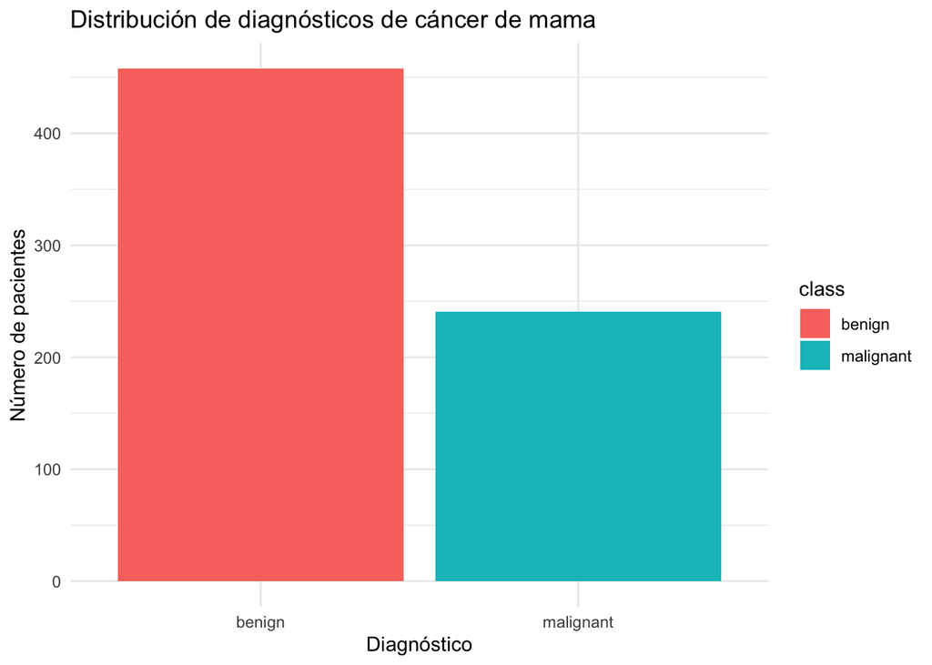

```r
ggplot(biopsy,
       aes(x=class, fill=class))+
geom_bar()+
labs(
title="Distribución de diagnósticos de cáncer de mama",
x="Diagnóstico",
y="Número de pacientes"
)+
theme_minimal()
```

*PREGUNTA 2: ¿El grosor celular cambia entre tumores benignos y malignos?*

1. Se define la Variable:

```r
library(dplyr)

biopsy <- biopsy %>%

  rename(Cl.thickness = V1)
```

2. Representación grafica:

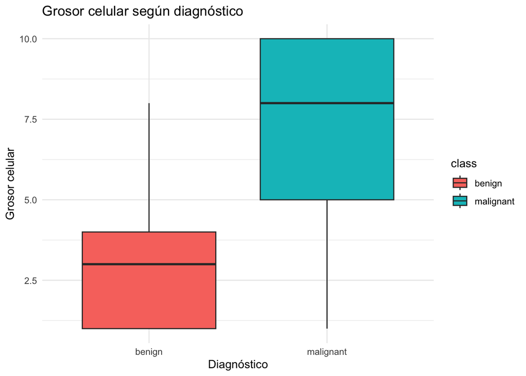

```r
ggplot(biopsy,
       aes(x=class,
           y=as.numeric(Cl.thickness),
           fill=class))+
geom_boxplot()+
labs(
title="Grosor celular según diagnóstico",
x="Diagnóstico",
y="Grosor celular"
)+
theme_minimal()
```

*PREGUNTA 3: ¿Existe una relación entre el grosor del cúmulo celular (V1) y la uniformidad del tamaño celular (V2), y esta relación difiere entre tumores benignos y malignos?*

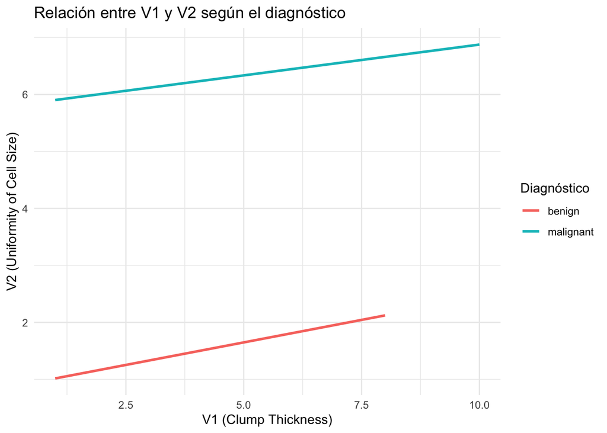

```r
ggplot(biopsy, aes(x = Cl.thickness, y = V2, color = class)) +

  geom_smooth(method = "lm", se = FALSE) +

  labs(

    title = "Relación entre V1 y V2 según el diagnóstico",

    x = "V1 (Clump Thickness)",

    y = "V2 (Uniformity of Cell Size)",

    color = "Diagnóstico"

  ) +

  theme_minimal()
```

CONLUSIÓN: Los tumores malignos presentan mayores valores de grosor celular (V1) y uniformidad del tamaño celular (V2) que los tumores benignos. Además, existe una tendencia positiva entre ambas variables, indicando que estas características podrían contribuir a diferenciar ambos tipos de tumores.